# Mota & Houzel 2015 figures and anaylises

Fernanda Hansen P. de Moraes and Victor B. B. Mello

01/11/2021

```r
## Define o diretorio de trabalho/Working Directory
setwd("~/GitHub/MH2015")

## Instala os pacotes necessarios - retirar os comentarios se for rodar pela primeira vez
# install.packages("tidyverse")
# install.packages("ggpubr")

## Chama os pacotes necessarios
library(readxl)
library(tidyverse)
library(ggpubr)
```

```r
## Importa os dados
dados_MH2015 <- read_excel("dados_Bruno_etal_Nature_UniversalScaling.xls")
View(dados_MH2015)

## Renomeia as colunas
colnames(dados_MH2015)[3] <- "TotalArea"
colnames(dados_MH2015)[5] <- "AvgThickness"
```

Precisamos calcular a área exposta a partir da área total e do Folding Index (FI ou localGI)

$$FoldingIndex = TotalArea/ExposedArea$$
$$\therefore$$
$$ExposedArea=TotalArea/FoldingIndex$$

```r
## Calcular area exposta a partir da area total e do folding index (FI ou localGI)
dados_MH2015 <- dados_MH2015 %>%
  mutate(ExposedArea = TotalArea/FI)
```

# Figura 1

Folding index scales across all gyrencephalic species in the combined data sets as power functions of …

## Figura 1D - total cortical area

“exponent 0.257 +- 0.014”

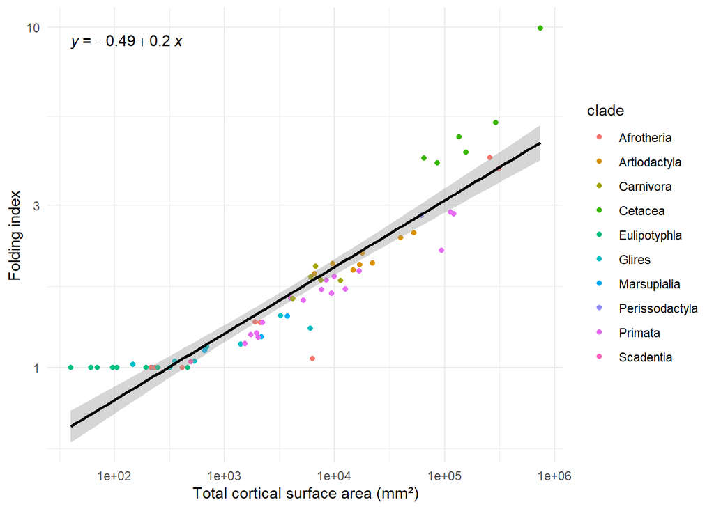

```r
ggplot(dados_MH2015, aes(x = TotalArea, y = FI)) +
  geom_point(aes(color = clade)) +
  scale_x_log10() +
  scale_y_log10() +
  labs(x = "Total cortical surface area (mm²)", y = "Folding index") +
  theme_minimal() +
  stat_smooth(method = "lm", color = "black") +
  stat_regline_equation()
```

“(r2 = 0.872, P < 0.0001)”

```r
cor <- cor.test(log10(dados_MH2015$TotalArea), log10(dados_MH2015$FI))
cor
```

```
##
##  Pearson's product-moment correlation
##
## data:  log10(dados_MH2015$TotalArea) and log10(dados_MH2015$FI)
## t = 18.923, df = 63, p-value < 2.2e-16
## alternative hypothesis: true correlation is not equal to 0
## 95 percent confidence interval:
##  0.8750865 0.9519551
## sample estimates:
##       cor
## 0.9221653
```

```r
paste("R2 = ", signif(cor$estimate^2, 2))
```

```
## [1] "R2 =  0.85"
```

*provavelmente a falta dos outros dados está levando a essa diferenca*

Segundo a legenda da figura: “Folding index scales across all gyrencephalic species in the combined data sets as power functions”. Para ser girencefálica, a especie tem que ter FI > 1 (Area total > Area exposta que necessariamente precisa ter giros e sulcos para existir no format de um cérebro).

Assim, testando se a gente usar apenas um subconjunto dos dados, com FI > 1.

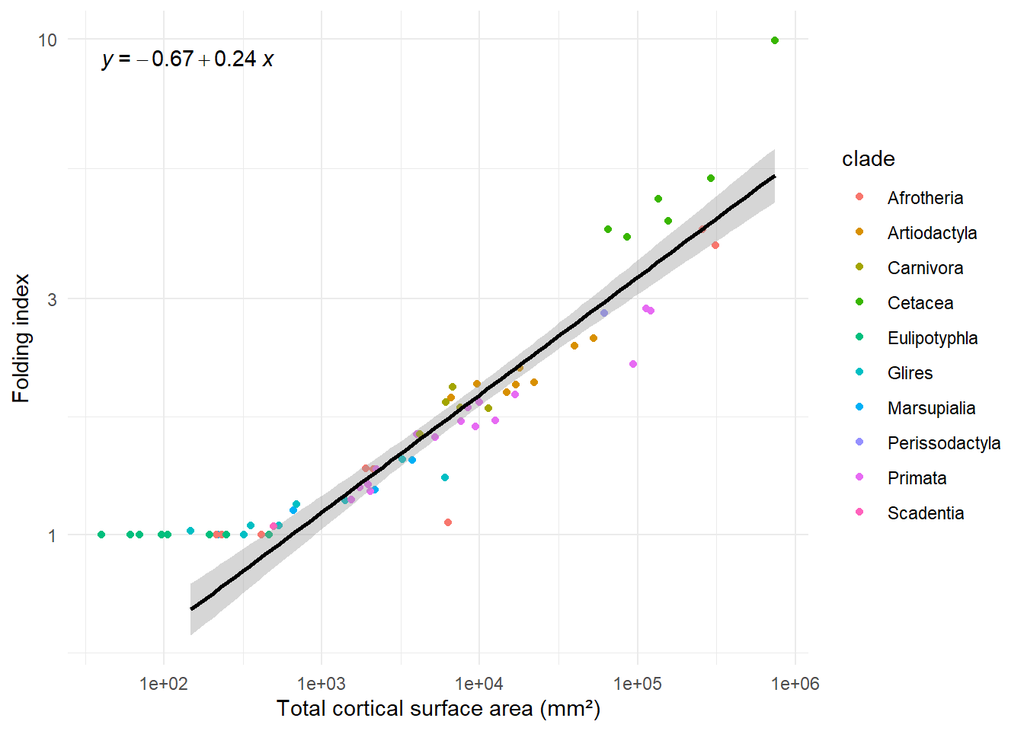

```r
ggplot(dados_MH2015, aes(x = TotalArea, y = FI)) +
  geom_point(aes(color = clade)) +
  scale_x_log10() +
  scale_y_log10() +
  labs(x = "Total cortical surface area (mm²)", y = "Folding index") +
  theme_minimal() +
  stat_smooth(data = subset(dados_MH2015, FI >1), method = "lm", color = "black") +
  # stat_smooth(method = "lm", color = "#336600", alpha = 0.4) +
  stat_regline_equation(data = subset(dados_MH2015, FI >1))
```

Verificando o expoente com o desvio padrao (“exponent 0.257 +- 0.014”):

```r
lm <- lm(log10(FI) ~ log10(TotalArea), filter(dados_MH2015, FI > 1))
summary(lm)
```

```
##
## Call:
## lm(formula = log10(FI) ~ log10(TotalArea), data = filter(dados_MH2015,
##     FI > 1))
##
## Residuals:
##      Min       1Q   Median       3Q      Max
## -0.20972 -0.03770 -0.01037  0.03673  0.27153
##
## Coefficients:
##                  Estimate Std. Error t value Pr(>|t|)
## (Intercept)      -0.66572    0.05313  -12.53   <2e-16 ***
## log10(TotalArea)  0.23708    0.01307   18.14   <2e-16 ***
## ---
## Signif. codes:  0 '***' 0.001 '**' 0.01 '*' 0.05 '.' 0.1 ' ' 1
##
## Residual standard error: 0.07893 on 50 degrees of freedom
## Multiple R-squared:  0.8681, Adjusted R-squared:  0.8655
## F-statistic: 329.1 on 1 and 50 DF,  p-value: < 2.2e-16
```

“(r2 = 0.872, P < 0.0001)”

```r
cor <- cor.test(log10(filter(dados_MH2015, FI > 1)$TotalArea), log10(filter(dados_MH2015, FI > 1)$FI))
cor
```

```
##
##  Pearson's product-moment correlation
##
## data:  log10(filter(dados_MH2015, FI > 1)$TotalArea) and log10(filter(dados_MH2015, FI > 1)$FI)
## t = 18.141, df = 50, p-value < 2.2e-16
## alternative hypothesis: true correlation is not equal to 0
## 95 percent confidence interval:
##  0.8834595 0.9604206
## sample estimates:
##       cor
## 0.9317244
```

```r
paste("R2 = ", signif(cor$estimate^2, 2))
```

```
## [1] "R2 =  0.87"
```

*alguma coisa ainda esta errada, acho que é a falta dos outros dados*

## Figura 1E - average cortical thickness

“with a non significant exponent”

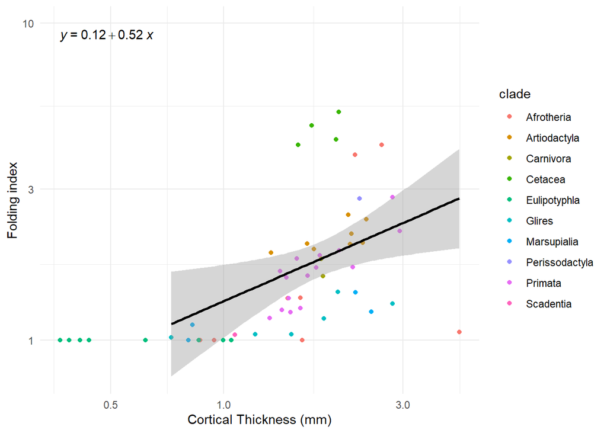

```r
ggplot(dados_MH2015, aes(x = AvgThickness, y = FI)) +
  geom_point(aes(color = clade)) +
  scale_x_log10() +
  scale_y_log10() +
  labs(x = "Cortical Thickness (mm)", y = "Folding index") +
  theme_minimal() +
  stat_smooth(data = subset(dados_MH2015, FI >1), method = "lm", color = "black") +
  # stat_smooth(method = "lm", color = "#336600", alpha = 0.4) +
  stat_regline_equation(data = subset(dados_MH2015, FI >1))
```

Verificando o expoente com o desvio padrao:

```r
lm <- lm(log10(FI) ~ log10(AvgThickness), filter(dados_MH2015, FI > 1))
summary(lm)
```

```
##
## Call:
## lm(formula = log10(FI) ~ log10(AvgThickness), data = filter(dados_MH2015,
##     FI > 1))
##
## Residuals:
##      Min       1Q   Median       3Q      Max
## -0.42167 -0.11658 -0.02073  0.06252  0.43782
##
## Coefficients:
##                     Estimate Std. Error t value Pr(>|t|)
## (Intercept)          0.12308    0.05688   2.164   0.0361 *
## log10(AvgThickness)  0.51712    0.19585   2.640   0.0115 *
## ---
## Signif. codes:  0 '***' 0.001 '**' 0.01 '*' 0.05 '.' 0.1 ' ' 1
##
## Residual standard error: 0.181 on 43 degrees of freedom
##   (7 observations deleted due to missingness)
## Multiple R-squared:  0.1395, Adjusted R-squared:  0.1195
## F-statistic: 6.972 on 1 and 43 DF,  p-value: 0.01149
```

“(r2 = 0.054, P = 0.1430)”

```r
cor <- cor.test(log10(filter(dados_MH2015, FI > 1)$AvgThickness), log10(filter(dados_MH2015, FI > 1)$FI))
cor
```

```
##
##  Pearson's product-moment correlation
##
## data:  log10(filter(dados_MH2015, FI > 1)$AvgThickness) and log10(filter(dados_MH2015, FI > 1)$FI)
## t = 2.6404, df = 43, p-value = 0.01149
## alternative hypothesis: true correlation is not equal to 0
## 95 percent confidence interval:
##  0.08983008 0.60114036
## sample estimates:
##       cor
## 0.3735151
```

```r
paste("R2 = ", signif(cor$estimate^2, 2))
```

```
## [1] "R2 =  0.14"
```

## Figura 1F

“Total cortical surface area varies across lissencephalic species as a linear function of the exposed surface area, but as a power function with an exponent of 1.242 +- 0.018 across noncetacean gyrencephalic species (r2 = 0.992, P < 0.0001).”

“exponent of 1.242 +- 0.018 across **noncetacean** gyrencephalic species”

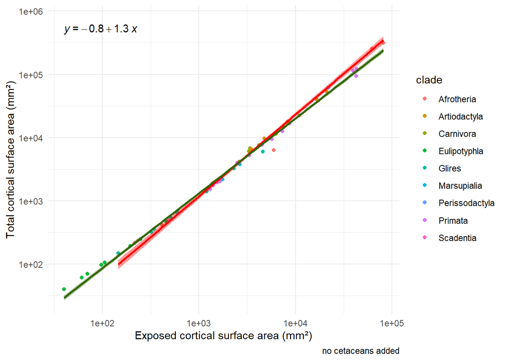

```r
ggplot(filter(dados_MH2015, clade !="Cetacea"), aes(x = ExposedArea, y = TotalArea)) +
  geom_point(aes(color = clade)) +
  scale_x_log10() +
  scale_y_log10() +
  labs(x = "Exposed cortical surface area (mm²)", y = "Total cortical surface area (mm²)", caption = "no cetaceans added") +
  theme_minimal() +
  stat_smooth(data = subset(dados_MH2015, FI >1), method = "lm", color = "red", fill = "red") +
  stat_smooth(method = "lm", color = "#336600", fill = "#336600") +
  stat_regline_equation(data = subset(dados_MH2015, FI >1))
```

Verificando o expoente com o desvio padrao:

```r
lm <- lm(log10(TotalArea) ~ log10(ExposedArea), filter(dados_MH2015, FI > 1, clade !="Cetacea"))
summary(lm)
```

```
##
## Call:
## lm(formula = log10(TotalArea) ~ log10(ExposedArea), data = filter(dados_MH2015,
##     FI > 1, clade != "Cetacea"))
##
## Residuals:
##       Min        1Q    Median        3Q       Max
## -0.236672 -0.023237  0.000837  0.025351  0.125911
##
## Coefficients:
##                    Estimate Std. Error t value Pr(>|t|)
## (Intercept)        -0.58514    0.05428  -10.78 6.26e-14 ***
## log10(ExposedArea)  1.22446    0.01490   82.18  < 2e-16 ***
## ---
## Signif. codes:  0 '***' 0.001 '**' 0.01 '*' 0.05 '.' 0.1 ' ' 1
##
## Residual standard error: 0.0607 on 44 degrees of freedom
## Multiple R-squared:  0.9935, Adjusted R-squared:  0.9934
## F-statistic:  6753 on 1 and 44 DF,  p-value: < 2.2e-16
```

“(r2 = 0.992, P < 0.0001)”

```r
cor <- cor.test(log10(filter(dados_MH2015, FI > 1, clade !="Cetacea")$ExposedArea), log10(filter(dados_MH2015, FI > 1, clade !="Cetacea")$TotalArea))
cor
```

```
##
##  Pearson's product-moment correlation
##
## data:  log10(filter(dados_MH2015, FI > 1, clade != "Cetacea")$ExposedArea) and log10(filter(dados_MH2015, FI > 1, clade != "Cetacea")$TotalArea)
## t = 82.177, df = 44, p-value < 2.2e-16
## alternative hypothesis: true correlation is not equal to 0
## 95 percent confidence interval:
##  0.9941137 0.9982155
## sample estimates:
##      cor
## 0.996758
```

```r
paste("R2 = ", signif(cor$estimate^2, 2))
```

```
## [1] "R2 =  0.99"
```

# Figura 3

## Figura 3A

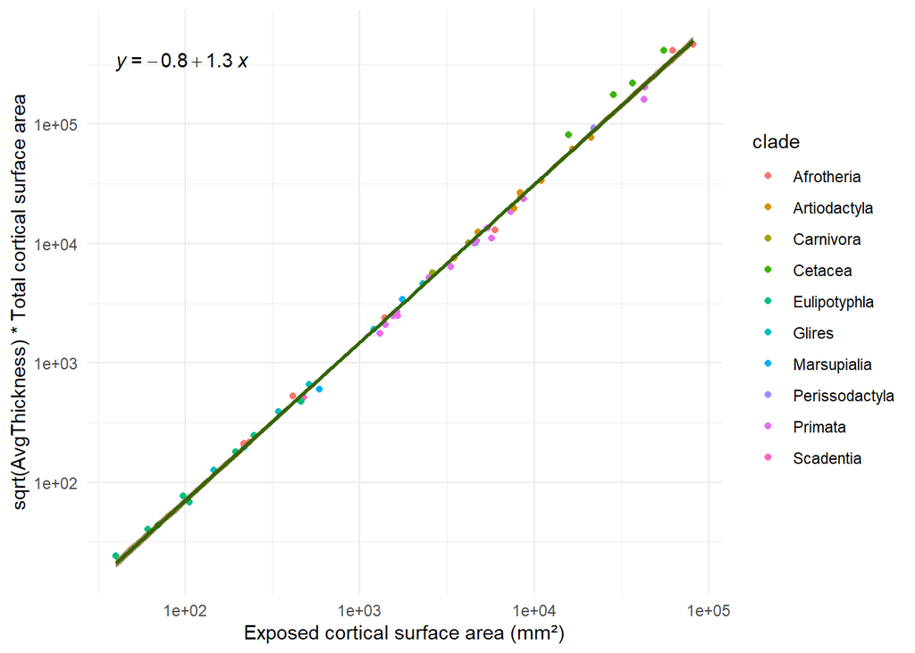

```r
ggplot(filter(dados_MH2015), aes(x = ExposedArea, y = TotalArea*sqrt(AvgThickness))) +
  geom_point(aes(color = clade)) +
  scale_x_log10() +
  scale_y_log10() +
  labs(x = "Exposed cortical surface area (mm²)", y = "sqrt(AvgThickness) * Total cortical surface area") +
  theme_minimal() +
  stat_smooth(data = subset(dados_MH2015), method = "lm", color = "red", fill = "red") +
  stat_smooth(method = "lm", color = "#336600", fill = "#336600") +
  stat_regline_equation(data = subset(dados_MH2015))
```

Verificando o expoente com o desvio padrao:

```r
lm <- lm(log10(TotalArea*sqrt(AvgThickness)) ~ log10(ExposedArea), filter(dados_MH2015))
summary(lm)
```

```
##
## Call:
## lm(formula = log10(TotalArea * sqrt(AvgThickness)) ~ log10(ExposedArea),
##     data = filter(dados_MH2015))
##
## Residuals:
##       Min        1Q    Median        3Q       Max
## -0.123303 -0.039147 -0.000794  0.031742  0.154620
##
## Coefficients:
##                     Estimate Std. Error t value Pr(>|t|)
## (Intercept)        -0.802916   0.032134  -24.99   <2e-16 ***
## log10(ExposedArea)  1.324698   0.009292  142.56   <2e-16 ***
## ---
## Signif. codes:  0 '***' 0.001 '**' 0.01 '*' 0.05 '.' 0.1 ' ' 1
##
## Residual standard error: 0.05874 on 55 degrees of freedom
##   (15 observations deleted due to missingness)
## Multiple R-squared:  0.9973, Adjusted R-squared:  0.9973
## F-statistic: 2.032e+04 on 1 and 55 DF,  p-value: < 2.2e-16
```

```r
cor <- cor.test(log10(dados_MH2015$ExposedArea), log10(dados_MH2015$TotalArea*sqrt(dados_MH2015$AvgThickness)))
cor
```

```
##
##  Pearson's product-moment correlation
##
## data:  log10(dados_MH2015$ExposedArea) and log10(dados_MH2015$TotalArea * sqrt(dados_MH2015$AvgThickness))
## t = 142.56, df = 55, p-value < 2.2e-16
## alternative hypothesis: true correlation is not equal to 0
## 95 percent confidence interval:
##  0.9976991 0.9992077
## sample estimates:
##       cor
## 0.9986497
```

```r
paste("R2 = ", signif(cor$estimate^2, 2))
```

```
## [1] "R2 =  1"
```

### Non-cetaceans

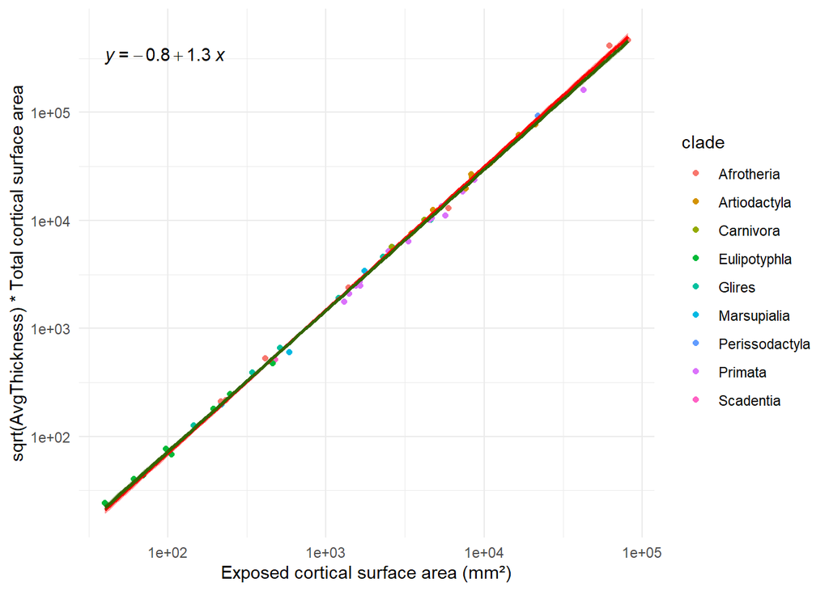

```r
ggplot(filter(dados_MH2015, clade != "Cetacea"), aes(x = ExposedArea, y = TotalArea*sqrt(AvgThickness))) +
  geom_point(aes(color = clade)) +
  scale_x_log10() +
  scale_y_log10() +
  labs(x = "Exposed cortical surface area (mm²)", y = "sqrt(AvgThickness) * Total cortical surface area") +
  theme_minimal() +
  stat_smooth(data = subset(dados_MH2015), method = "lm", color = "red", fill = "red") +
  stat_smooth(method = "lm", color = "#336600", fill = "#336600") +
  stat_regline_equation(data = subset(dados_MH2015))
```

```r
lm <- lm(log10(TotalArea*sqrt(AvgThickness)) ~ log10(ExposedArea), filter(dados_MH2015, clade != "Cetacea"))
summary(lm)
```

```
##
## Call:
## lm(formula = log10(TotalArea * sqrt(AvgThickness)) ~ log10(ExposedArea),
##     data = filter(dados_MH2015, clade != "Cetacea"))
##
## Residuals:
##       Min        1Q    Median        3Q       Max
## -0.103741 -0.028416  0.007858  0.029655  0.112890
##
## Coefficients:
##                     Estimate Std. Error t value Pr(>|t|)
## (Intercept)        -0.750604   0.024905  -30.14   <2e-16 ***
## log10(ExposedArea)  1.305553   0.007396  176.51   <2e-16 ***
## ---
## Signif. codes:  0 '***' 0.001 '**' 0.01 '*' 0.05 '.' 0.1 ' ' 1
##
## Residual standard error: 0.0433 on 51 degrees of freedom
##   (12 observations deleted due to missingness)
## Multiple R-squared:  0.9984, Adjusted R-squared:  0.9983
## F-statistic: 3.116e+04 on 1 and 51 DF,  p-value: < 2.2e-16
```

```r
cor <- cor.test(log10(filter(dados_MH2015, clade != "Cetacea")$ExposedArea), log10(filter(dados_MH2015, clade != "Cetacea")$TotalArea*sqrt(filter(dados_MH2015, clade != "Cetacea")$AvgThickness)))
cor
```

```
##
##  Pearson's product-moment correlation
##
## data:  log10(filter(dados_MH2015, clade != "Cetacea")$ExposedArea) and log10(filter(dados_MH2015, clade != "Cetacea")$TotalArea * sqrt(filter(dados_MH2015, clade != "Cetacea")$AvgThickness))
## t = 176.51, df = 51, p-value < 2.2e-16
## alternative hypothesis: true correlation is not equal to 0
## 95 percent confidence interval:
##  0.9985774 0.9995303
## sample estimates:
##       cor
## 0.9991825
```

```r
paste("R2 = ", signif(cor$estimate^2, 2))
```

```
## [1] "R2 =  1"
```

## Figura 3B

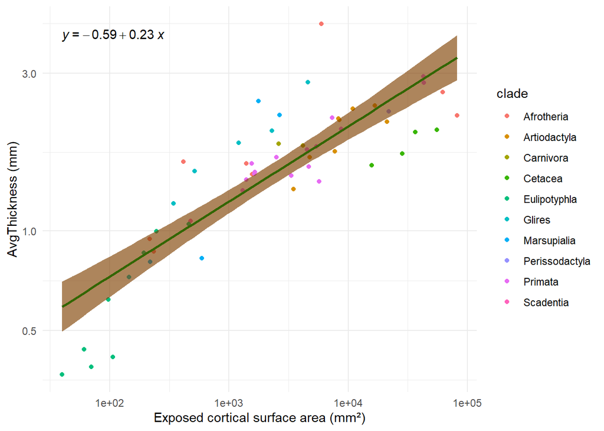

```r
ggplot(filter(dados_MH2015), aes(x = ExposedArea, y = AvgThickness)) +
  geom_point(aes(color = clade)) +
  scale_x_log10() +
  scale_y_log10() +
  labs(x = "Exposed cortical surface area (mm²)", y = "AvgThickness (mm)") +
  theme_minimal() +
  stat_smooth(method = "lm", color = "red", fill = "red") +
  stat_smooth(method = "lm", color = "#336600", fill = "#336600") +
  stat_regline_equation()
```

Cada familia separada:

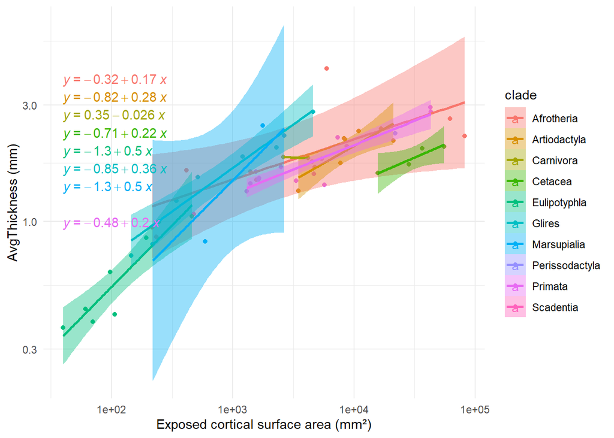

```r
ggplot(filter(dados_MH2015), aes(x = ExposedArea, y = AvgThickness, color = clade, fill = clade)) +
  geom_point() +
  scale_x_log10() +
  scale_y_log10() +
  labs(x = "Exposed cortical surface area (mm²)", y = "AvgThickness (mm)") +
  theme_minimal() +
  stat_smooth(method = "lm", alpha = 0.4) +
  stat_regline_equation()
```

Verificando o expoente com o desvio padrao:

```r
lm <- lm(log10(AvgThickness) ~ log10(ExposedArea), filter(dados_MH2015, FI > 1))
summary(lm)
```

```
##
## Call:
## lm(formula = log10(AvgThickness) ~ log10(ExposedArea), data = filter(dados_MH2015,
##     FI > 1))
##
## Residuals:
##      Min       1Q   Median       3Q      Max
## -0.20506 -0.06129 -0.00326  0.04694  0.35466
##
## Coefficients:
##                    Estimate Std. Error t value Pr(>|t|)
## (Intercept)        -0.29120    0.09011  -3.232  0.00236 **
## log10(ExposedArea)  0.14915    0.02422   6.159 2.15e-07 ***
## ---
## Signif. codes:  0 '***' 0.001 '**' 0.01 '*' 0.05 '.' 0.1 ' ' 1
##
## Residual standard error: 0.1027 on 43 degrees of freedom
##   (7 observations deleted due to missingness)
## Multiple R-squared:  0.4687, Adjusted R-squared:  0.4563
## F-statistic: 37.93 on 1 and 43 DF,  p-value: 2.148e-07
```

```r
cor <- cor.test(log10(filter(dados_MH2015, FI > 1)$ExposedArea), log10(filter(dados_MH2015, FI > 1)$AvgThickness))
cor
```

```
##
##  Pearson's product-moment correlation
##
## data:  log10(filter(dados_MH2015, FI > 1)$ExposedArea) and log10(filter(dados_MH2015, FI > 1)$AvgThickness)
## t = 6.1587, df = 43, p-value = 2.148e-07
## alternative hypothesis: true correlation is not equal to 0
## 95 percent confidence interval:
##  0.4894155 0.8144644
## sample estimates:
##       cor
## 0.6845998
```

```r
paste("R2 = ", signif(cor$estimate^2, 2))
```

```
## [1] "R2 =  0.47"
```